This question involves the use of linear regression on the `Auto` data set from the textbook library `ISLR`. You could do `?Auto` to check the description of the dataset.

```r
library(tidyverse)
library(ISLR)
head(Auto)
```

```
##   mpg cylinders displacement horsepower weight acceleration year origin
## 1  18         8          307        130   3504         12.0   70      1
## 2  15         8          350        165   3693         11.5   70      1
## 3  18         8          318        150   3436         11.0   70      1
## 4  16         8          304        150   3433         12.0   70      1
## 5  17         8          302        140   3449         10.5   70      1
## 6  15         8          429        198   4341         10.0   70      1
##                        name
## 1 chevrolet chevelle malibu
## 2         buick skylark 320
## 3        plymouth satellite
## 4             amc rebel sst
## 5               ford torino
## 6          ford galaxie 500
```

1. Use the `lm()` function to perform a linear regression with `mpg` as the response and `horsepower` as the predictor.

```r
model <- lm(formula = mpg ~ horsepower, data = Auto)
model
```

```
##
## Call:
## lm(formula = mpg ~ horsepower, data = Auto)
##
## Coefficients:
## (Intercept)   horsepower
##     39.9359      -0.1578
```

2. Plot the response and the predictor as well as the regression line. Any comment?

A scatterplot of the data

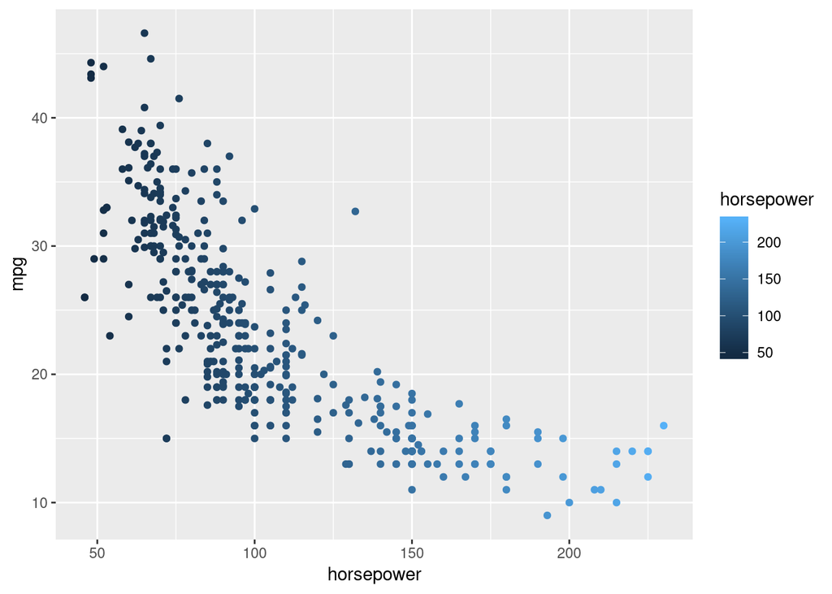

```r
ggplot(Auto, aes(x = horsepower, y = mpg, color = horsepower)) + geom_point()
```

If we include the regression line of our model, we can see the fit.

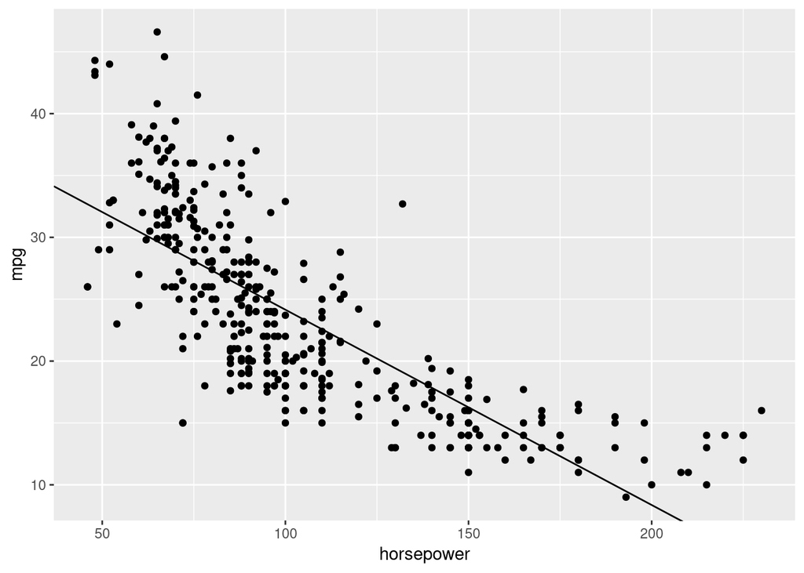

```r
ggplot(Auto, aes(x = horsepower, y = mpg)) + geom_point() + geom_abline(slope = model$coefficients[2], intercept = model$coefficients[1])
```

3. What’s the prediction of `mpg` if `horsepower` is 100?

```r
predict.lm(model, new = data.frame(horsepower = 100))
```

```
##        1
## 24.15139
```

The predicted miles per gallon is `24.15139`.

4. What’s the value of `R^2`?

```r
summary(model)
```

```
##
## Call:
## lm(formula = mpg ~ horsepower, data = Auto)
##
## Residuals:
##      Min       1Q   Median       3Q      Max
## -13.5710  -3.2592  -0.3435   2.7630  16.9240
##
## Coefficients:
##              Estimate Std. Error t value Pr(>|t|)
## (Intercept) 39.935861   0.717499   55.66   <2e-16 ***
## horsepower  -0.157845   0.006446  -24.49   <2e-16 ***
## ---
## Signif. codes:  0 '***' 0.001 '**' 0.01 '*' 0.05 '.' 0.1 ' ' 1
##
## Residual standard error: 4.906 on 390 degrees of freedom
## Multiple R-squared:  0.6059, Adjusted R-squared:  0.6049
## F-statistic: 599.7 on 1 and 390 DF,  p-value: < 2.2e-16
```

The value of `R^2` in the model is `0.6059`.

### Model transformations

5. Try a few different transformations of the predictor. And which is the best one you could find?

#### `log`

```r
model_log <-  lm(data = Auto, formula = mpg ~ I(log(horsepower)))
summary(model_log)
```

```
##
## Call:
## lm(formula = mpg ~ I(log(horsepower)), data = Auto)
##
## Residuals:
##      Min       1Q   Median       3Q      Max
## -14.2299  -2.7818  -0.2322   2.6661  15.4695
##
## Coefficients:
##                    Estimate Std. Error t value Pr(>|t|)
## (Intercept)        108.6997     3.0496   35.64   <2e-16 ***
## I(log(horsepower)) -18.5822     0.6629  -28.03   <2e-16 ***
## ---
## Signif. codes:  0 '***' 0.001 '**' 0.01 '*' 0.05 '.' 0.1 ' ' 1
##
## Residual standard error: 4.501 on 390 degrees of freedom
## Multiple R-squared:  0.6683, Adjusted R-squared:  0.6675
## F-statistic: 785.9 on 1 and 390 DF,  p-value: < 2.2e-16
```

And a plot of the new model:

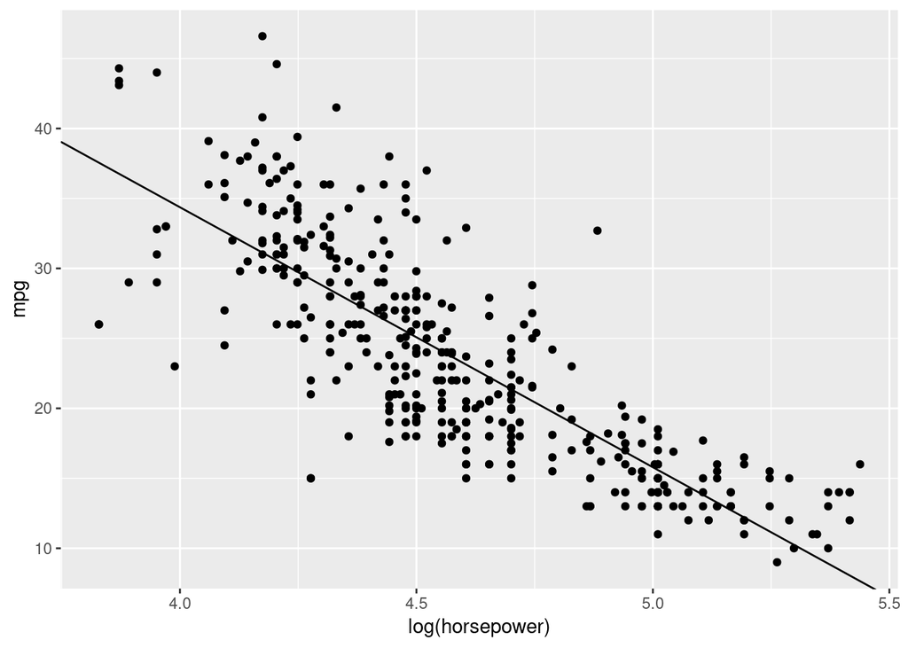

```r
ggplot(Auto, aes(x = log(horsepower), y = mpg)) + geom_point() + geom_abline(slope = model_log$coefficients[2], intercept = model_log$coefficients[1])
```

#### `reciprocal`

```r
model_inv <-  lm(data = Auto, formula = I(1/mpg) ~ horsepower)
summary(model_inv)
```

```
##
## Call:
## lm(formula = I(1/mpg) ~ horsepower, data = Auto)
##
## Residuals:
##       Min        1Q    Median        3Q       Max
## -0.031709 -0.005296 -0.001076  0.005673  0.030843
##
## Coefficients:
##              Estimate Std. Error t value Pr(>|t|)
## (Intercept) 9.218e-03  1.265e-03    7.29 1.74e-12 ***
## horsepower  3.695e-04  1.136e-05   32.53  < 2e-16 ***
## ---
## Signif. codes:  0 '***' 0.001 '**' 0.01 '*' 0.05 '.' 0.1 ' ' 1
##
## Residual standard error: 0.008646 on 390 degrees of freedom
## Multiple R-squared:  0.7307, Adjusted R-squared:   0.73
## F-statistic:  1058 on 1 and 390 DF,  p-value: < 2.2e-16
```

And a plot of this model:

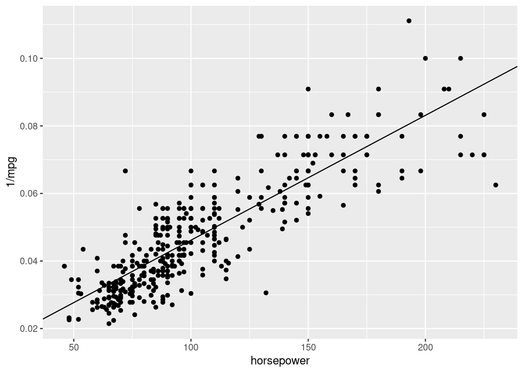

```r
ggplot(Auto, aes(x = horsepower, y = 1/mpg)) + geom_point() + geom_abline(slope = model_inv$coefficients[2], intercept = model_inv$coefficients[1])
```

With an `R^2` value of `.7307` this may may be a better fit than the other models considered. Since the dataset contains multiple variables, but we are only considereing one independent variable in the model, it may be that this variation represents the best possible fit we can find for the data when only considereng one of the variables.